- https://pandas.pydata.org/pandas-docs/stable/user_guide/visualization.html#density-plot
- 히스토그램 그래프를 곡선형태로 그려줄 때 사용하는 함수
- 가우시안 분포(정규분포)으로 그려서 곡선으로 표현

# Kernel Density Estimate plot

- [Kernel density estimation - Wikipedia](https://en.wikipedia.org/wiki/Kernel_density_estimation)
- 통계에서 커널 밀도 추정 (KDE)은 임의 변수의 확률 밀도 함수 (PDF)를 추정하는 비모수적 방법이다. 이 함수는 가우스 커널을 사용하며 자동 대역폭 결정을 포함한다.
- [비모수 통계 - 위키백과, 우리 모두의 백과사전](https://ko.wikipedia.org/wiki/%EB%B9%84%EB%AA%A8%EC%88%98_%ED%86%B5%EA%B3%84)
- 커널 밀도 추정치는 히스토그램 과 밀접한 관련이 있지만 적절한 커널을 사용하여 매끄럽고 연속성과 같은 속성을 부여 할 수 있다.
- 커널 함수는 원점을 중심으로 대칭이며 적분값이 1인 함수다.

### 확률 밀도 함수( probability density function )

- [확률 밀도 함수 - 위키백과, 우리 모두의 백과사전](https://ko.wikipedia.org/wiki/%ED%99%95%EB%A5%A0_%EB%B0%80%EB%8F%84_%ED%95%A8%EC%88%98)
- [확률 변수 - 위키백과, 우리 모두의 백과사전](https://ko.wikipedia.org/wiki/%ED%99%95%EB%A5%A0_%EB%B3%80%EC%88%98)

### 정규분포

- 확률론과 통계학에서, 정규 분포(normal distribution) 또는 가우시안 분포(Gaussian distribution)는 연속 확률 분포의 하나이다. 정규분포는 수집된 자료의 분포를 근사하는 데에 자주 사용되며, 이것은 중심극한정리에 의하여 독립적인 확률변수들의 평균은 정규분포에 가까워지는 성질이 있기 때문이다. - 출처 : [정규 분포 - 위키백과, 우리 모두의 백과사전](https://ko.wikipedia.org/wiki/%EC%A0%95%EA%B7%9C_%EB%B6%84%ED%8F%AC)

```python
import pandas as pd
import numpy as np
import matplotlib.pyplot as plt
import matplotlib as mpl

%matplotlib inline

# 한글폰트 사용시 그래프에서 마이너스 폰트 깨지는 문제에 대한 대처
mpl.rcParams['axes.unicode_minus'] = False
```

```python
ser = pd.Series(np.random.randn(1000))
```

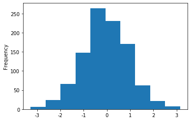

```python
ser.plot.hist()
```

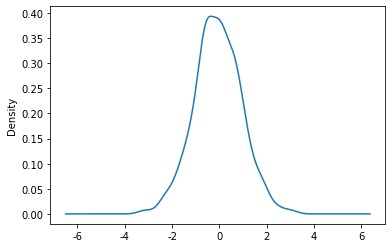

```python
ser.plot.density()
```

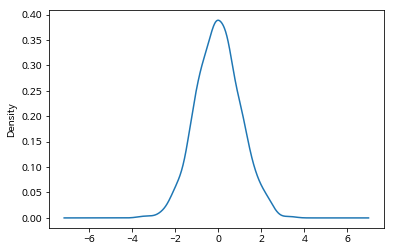

```python
ser.plot.kde()
```